# Lecture Four 重用机制（二）#

## 类和面向对象的程序设计

类（class）是Python语言实现重用功能的重要概念，也是基于对象编程（Object-Oriented Programming）的重要概念。基于对象的编程的提出，是计算机科学的一项重大发展，它使得程序编写更加高效、更加容易，也使得管理大规模程序更为方便。

**理解类的概念需要首先理解对象（object）的概念**。哲学地说，**世界可以看作是一个实体的集合，实体之间相关关联，相互作用**。因此，如果能够描述清楚实体以及实体之间的互动关系，也就描述清楚了这个世界。当我们的设计一个程序时，需要分析需求**涉及到哪些实体**，**实体本身有哪些属性**，**实体之间是怎样相互作用的**。将这些概念分析清楚了，然后就可以运用Python语言中“类”的概念来描述实体、实体的属性以及实体之间的作用关系，由此完成了一个程序的设计。

### 类的结构

可以用一个类表示一个对象，或者一个概念。例如，对于“语言单位”这一概念，可以通过一个类来表示。在《大辞海》中，“语言单位”定义如下：

```
语言单位，语言学术语。即语言系统各结构层次的单位。可根据不同的标准划分出不同的单位。如法国马丁内划分语素和音位两类语言单位。法国班维尼斯特（E. Benveniste，1902—1977）划分区别性特征、音位、语素、词位、句子五类语言单位。索绪尔把语素、词、熟语（固定词组）称作语言单位，而把自由词组和句子划归言语单位。有人区分语音单位和语法单位，前者包括音素、音位、音节等，后者包括词素、词、词组（短语）、小句、句子等。也有人把词和熟语称为词汇单位，把义素和义位称为语义单位。此外，有的语言学家把词的结构模式和句子的结构模式亦称作语言单位。
句子是语言使用的基本单位。句子是指由词按照语法规则构成的，能表达一个完整的意思
```

在构建类的时候，需要注意的是类中的变量的作用域问题。其中的原则是： （1）所有class定义的代码内部是一个命名空间（namespace），即一个有名字的自我空间，在这个空间内，类内部的所有成员都是可访问的；有两种访问方式：**类成员**可通过class.访问,**类实例成员**通过self(或实例名称）访问； （2）在命名空间外部，类的公共成员是可访问的，私有成员不可访问。

```python
from nltk import word_tokenize

#################################################################################
## This part demonstrate how to use class and related mechanism to analyze linguistic unit.
## The following points are explained:
# (1) How class if defined;
# (2) The initial function and its use
# (3) Methods and the use of 'self'
# (4) Property: two ways of defining properties
# (5) Private vs non-private
# (6) How a class is used
# (7) Explain encapsulation

class LingUnit(object):

    def __init__(self, ling_exp):
        self.exp = ling_exp
        ## To make a method or attribute private and inaccessible from the outside,
        ## start its name with two underscores
        self.__size = self.getLength()
        self.size_plus_1 = len(ling_exp) + 1

    def getLength(self):
        return len(self.exp)

    def tokenize(self):
        return self.exp

    @classmethod
    def typeof(cls):
        return "This is a LingUnit"

    ## The same as self.size
    size_by_method = property(getLength)
    size = 0

lu = LingUnit("take place")
print( lu.getLength() )
print(LingUnit.typeof())
try:
    print(lu.exp)
    print(lu.size_plus_1)
    print( lu.__size)

except Exception as e:
    print("ERROR",  e)
```

```
10
This is a LingUnit
take place
11
ERROR 'LingUnit' object has no attribute '__size'
```

### 类的继承

类的继承是概念之间关系在面向对象程序设计中的实现方式。概念之间存在上下层级关系。例如，在语言学概念中，语言单位可以区分为词、短语、句子和篇章等类型。那么这些就是语言单位的下义词。它们具有语言单位所具有的一般特征，同时，每一个下义概念又具有其自身特征。在运用Python概念编写时，我们就可以运用Python的继承机制，使得下义类能够继承上位概念的属性，同时又具有自身特有的属性。

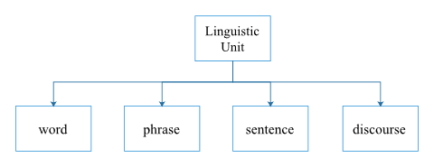

```python
###########################################################################
## Explain inheritance
## (1) Single inheritance,
## (2) The class uses all the methods in default

class Word(LingUnit):
    def __init__(self, ling_exp):
        #super(Word, self).__init__(ling_exp)
        LingUnit.__init__(self,ling_exp)

w = Word("takes")
print("Word length: ", w.getLength(), w.size_plus_1)
print("Result of word tokenization: ", w.tokenize())
print(LingUnit.typeof())
```

```
Word length:  5 6
Result of word tokenization:  takes
This is a LingUnit
```

概念层级中还有另一个重要概念：多重继承（multiple inheritance），也就是一个类可以有多个父类，从多个父类继承属性。在下面的例子中，句子既是一种语言单位，也是词语的列表。因此，需要多重继承机制来表达这个概念。

```python
###############################################################################
## Demonstrate the following:
## (1) Multiple inheritance
## (2) The sentence overrides some methods
## (3) How to inherit from a list
## (4) What 'yield' mean

class Sentence(LingUnit, list):

    def __init__(self, ling_exp):
        LingUnit.__init__(self, ling_exp)
        list.__init__(self)
        self.words = self.tokenize()

    ## over-ridden method
    def tokenize(self):
        return word_tokenize(self.exp)

    def getWordNumber(self):
        return len(self.words)

    word_num = property(getWordNumber)

    ## Functions for Item Access
    @property

    def length(self):
        return self.len(self.words)


    def __len__(self):
        return len(self.words)


    def __getitem__(self, key):
        return self.words[key]


    def __setitem__(self, key, value):
        self.words[key] = value


    def __delitem__(self, key):
        del self.words[key]

    ## Functions for iteration

    def __iter__(self):
        self.__curPstn = -1
        return self


    def __next__(self):
        self.__curPstn += 1
        if self.__curPstn < self.word_num:
            return self.words[self.__curPstn]
        else:
            raise StopIteration

    ## Generator ##
    def getWords(self):
        for w in self.words:
            yield w

## Deomo
s = Sentence("This takes time.")
print("Sentence length: ", s.getLength(), s.size)
print("Sentence tokenization result: ", s.tokenize())
print("Number of words in the sentence: ", len(s))
print("First word in the sentence: ", s[0])
print("Iteration:")
for w in s:
    print(w)

words = s.getWords()
print("Iterating the generator the first time:")
for w in words:
    print(w)
print("Iterating the generator the second time:")
for w in words:
    print(w)
```

```
Sentence length:  16 0
Sentence tokenization result:  ['This', 'takes', 'time', '.']
Number of words in the sentence:  4
First word in the sentence:  This
Iteration:
This
takes
time
.
Iterating the generator the first time:
This
takes
time
.
Iterating the generator the second time:
```

## Exercise

(1) Read the file in "nltk.corpus.reader.api.py" and "nltk.corpus.reader.plaintext.py" and answer the following questions:

```
a) What is the relationship between class CorpusReader and class PlainCorpusReader

b) Why is it that CorpusReader does not have the property self._word_tokenizer and self._sentence_tokenizer

c) Does PlainCorpusReader have an "open" method? Why or why not?
```